# 🚴‍♂️ Cyclists Bike Usage Analytics

**Objective:** Analyze How do annual members and casual riders use Cyclistic bikes differently?

**Dataset:** June 2025 Dataset

In this project, we explore how annual members and casual riders use Cyclistic bike-share services differently. Using one month of ride data from Chicago, we perform detailed data cleaning, transformation, and visualization. The analysis focuses on ride duration, trip timing, and station popularity. Insights from this study help inform marketing strategies aimed at converting casual riders into annual members.

```python
# library
import pandas as pd
import numpy as np
import matplotlib.pyplot as plt
import seaborn as sns
from datetime import datetime
import warnings
warnings.filterwarnings('ignore')

# For beautiful plots
sns.set(style="whitegrid", palette="pastel", font_scale=1.1)
```

```python
# load the data
df = pd.read_csv("202506-divvy-tripdata.csv")
```

```python
df.tail()
```

|  | ride_id | rideable_type | started_at | ended_at | start_station_name | start_station_id | end_station_name | end_station_id | start_lat | start_lng | end_lat | end_lng | member_casual |
| --- | --- | --- | --- | --- | --- | --- | --- | --- | --- | --- | --- | --- | --- |
| 678899 | E0858F13ABDC894F | electric_bike | 2025-06-21 13:37:56.984 | 2025-06-21 13:38:25.365 | NaN | NaN | NaN | NaN | 41.94 | -87.64 | 41.94 | -87.64 | casual |
| 678900 | 904C877CC3FF2E45 | electric_bike | 2025-06-21 13:42:39.211 | 2025-06-21 13:48:02.986 | NaN | NaN | NaN | NaN | 41.94 | -87.64 | 41.93 | -87.63 | casual |
| 678901 | 4630637206290091 | electric_bike | 2025-06-21 13:54:39.487 | 2025-06-21 14:49:01.173 | NaN | NaN | NaN | NaN | 41.89 | -87.62 | 41.88 | -87.63 | casual |
| 678902 | EEC9887F1B23B9B5 | electric_bike | 2025-06-20 22:52:33.912 | 2025-06-20 22:57:13.466 | NaN | NaN | NaN | NaN | 41.89 | -87.61 | 41.89 | -87.62 | casual |
| 678903 | F1BC673E1E90761B | electric_bike | 2025-06-20 20:15:11.630 | 2025-06-20 20:19:10.435 | NaN | NaN | NaN | NaN | 41.97 | -87.67 | 41.97 | -87.68 | casual |

```python
df.info()
```

```
<class 'pandas.core.frame.DataFrame'>
RangeIndex: 678904 entries, 0 to 678903
Data columns (total 13 columns):
 #   Column              Non-Null Count   Dtype
---  ------              --------------   -----
 0   ride_id             678904 non-null  object
 1   rideable_type       678904 non-null  object
 2   started_at          678904 non-null  object
 3   ended_at            678904 non-null  object
 4   start_station_name  528000 non-null  object
 5   start_station_id    528000 non-null  object
 6   end_station_name    522132 non-null  object
 7   end_station_id      522132 non-null  object
 8   start_lat           678904 non-null  float64
 9   start_lng           678904 non-null  float64
 10  end_lat             677916 non-null  float64
 11  end_lng             677916 non-null  float64
 12  member_casual       678904 non-null  object
dtypes: float64(4), object(9)
memory usage: 67.3+ MB
```

**Data Types**: 9 categorical/object columns and 4 numeric (float64) columns.

- Some missing values exist in station name/id and end location coordinates.
- These have been handled appropriately during data cleaning.

```python
df.describe()
```

|  | start_lat | start_lng | end_lat | end_lng |
| --- | --- | --- | --- | --- |
| count | 678904.000000 | 678904.000000 | 677916.000000 | 677916.000000 |
| mean | 41.906512 | -87.646219 | 41.907077 | -87.646583 |
| std | 0.042037 | 0.026982 | 0.042279 | 0.027191 |
| min | 41.648501 | -87.890000 | 41.490000 | -88.060000 |
| 25% | 41.883380 | -87.660000 | 41.883984 | -87.660000 |
| 50% | 41.900000 | -87.641170 | 41.900960 | -87.641190 |
| 75% | 41.931320 | -87.629634 | 41.932418 | -87.629912 |
| max | 42.070000 | -87.528232 | 42.170000 | -87.420000 |

```python
df.duplicated().sum()
```

```
np.int64(0)
```

We have no duplicate Values

```python
df.isnull().sum()
```

```
ride_id                    0
rideable_type              0
started_at                 0
ended_at                   0
start_station_name    150904
start_station_id      150904
end_station_name      156772
end_station_id        156772
start_lat                  0
start_lng                  0
end_lat                  988
end_lng                  988
member_casual              0
dtype: int64
```

```python
# we delete those data where both start and end station names are null
df = df.dropna(subset=['start_station_name', 'end_station_name'], how='all')
```

```python
# Drop rows with missing lat/lng (very few)
df.dropna(subset=['end_lat', 'end_lng'], inplace=True)
```

```python
print("Remaining rows after deletion:", df.shape[0])
```

```
Remaining rows after deletion: 602781
```

```python
df['start_station_name'].unique()
```

```
array(['Clark St & Armitage Ave', 'Dearborn Pkwy & Delaware Pl',
       'Clark St & Elm St', ...,
       'Public Rack - Central Ave & Pensacola Ave',
       'Public Rack - King Dr & 71st St',
       'Public Rack - Harper Ave & 63rd St'], dtype=object)
```

```python
# Fill missing station names with 'Unknown'
df['start_station_name'].fillna("Unknown", inplace=True)
df['end_station_name'].fillna("Unknown", inplace=True)
```

```python
# Fill missing IDs as 'Unknown' too
df['start_station_id'].fillna("Unknown", inplace=True)
df['end_station_id'].fillna("Unknown", inplace=True)
```

This cleaned dataset will now be used to explore how **annual members** and **casual riders** differ in their riding behavior and patterns.

```python
# Convert to datetime
df['started_at'] = pd.to_datetime(df['started_at'])
df['ended_at'] = pd.to_datetime(df['ended_at'])
```

```python
# Create ride duration in minutes
df['ride_duration_min'] = (df['ended_at'] - df['started_at']).dt.total_seconds() / 60
```

```python
# Remove negative or zero durations
df = df[df['ride_duration_min'] > 0]
```

```python
# Create time-based features
df['day_of_week'] = df['started_at'].dt.day_name()
df['hour'] = df['started_at'].dt.hour
df['date'] = df['started_at'].dt.date
```

```python
df.head()
```

|  | ride_id | rideable_type | started_at | ended_at | start_station_name | start_station_id | end_station_name | end_station_id | start_lat | start_lng | end_lat | end_lng | member_casual | ride_duration_min | day_of_week | hour | date |
| --- | --- | --- | --- | --- | --- | --- | --- | --- | --- | --- | --- | --- | --- | --- | --- | --- | --- |
| 0 | 0E43949BF937C7DA | electric_bike | 2025-06-05 21:24:56.104 | 2025-06-05 21:38:44.446 | Clark St & Armitage Ave | CHI00474 | Dearborn Pkwy & Delaware Pl | CHI00306 | 41.918306 | -87.636282 | 41.898969 | -87.629912 | member | 13.805700 | Thursday | 21 | 2025-06-05 |
| 1 | 1CDEA40FEAF21789 | classic_bike | 2025-06-14 13:03:34.478 | 2025-06-14 13:13:19.791 | Dearborn Pkwy & Delaware Pl | CHI00306 | Kingsbury St & Kinzie St | CHI00299 | 41.898969 | -87.629912 | 41.889177 | -87.638506 | member | 9.755217 | Saturday | 13 | 2025-06-14 |
| 2 | 7ECEB1638575575C | classic_bike | 2025-06-09 13:30:22.540 | 2025-06-09 13:39:53.640 | Dearborn Pkwy & Delaware Pl | CHI00306 | Kingsbury St & Kinzie St | CHI00299 | 41.898969 | -87.629912 | 41.889177 | -87.638506 | member | 9.518333 | Monday | 13 | 2025-06-09 |
| 3 | F275084E25F5A131 | electric_bike | 2025-06-15 12:48:13.321 | 2025-06-15 13:00:18.798 | Clark St & Elm St | CHI00281 | Unknown | Unknown | 41.902970 | -87.631300 | 41.920000 | -87.650000 | member | 12.091283 | Sunday | 12 | 2025-06-15 |
| 4 | F42E81C85AC722FB | electric_bike | 2025-06-19 07:54:26.103 | 2025-06-19 08:04:36.583 | Damen Ave & Cortland St | CHI00388 | Unknown | Unknown | 41.915983 | -87.677335 | 41.940000 | -87.690000 | member | 10.174667 | Thursday | 7 | 2025-06-19 |

```python
print("Total Valid Rides:", df.shape[0])
```

```
Total Valid Rides: 602781
```

```python
print("Average Duration (min):", round(df['ride_duration_min'].mean(), 2))
```

```
Average Duration (min): 16.91
```

```python
print("Unique Start Stations:", df['start_station_name'].nunique())
```

```
Unique Start Stations: 1377
```

```python
print("Bike Types:", df['rideable_type'].unique())
```

```
Bike Types: ['electric_bike' 'classic_bike']
```

```python
print("User Types:", df['member_casual'].value_counts())
```

```
User Types: member_casual
member    348784
casual    253997
Name: count, dtype: int64
```

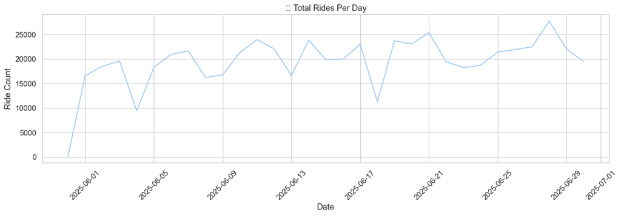

```python
daily = df.groupby('date').size()
plt.figure(figsize=(14,5))
sns.lineplot(x=daily.index, y=daily.values)
plt.title("📅 Total Rides Per Day")
plt.xlabel("Date")
plt.ylabel("Ride Count")
plt.xticks(rotation=45)
plt.tight_layout()
plt.show()
```

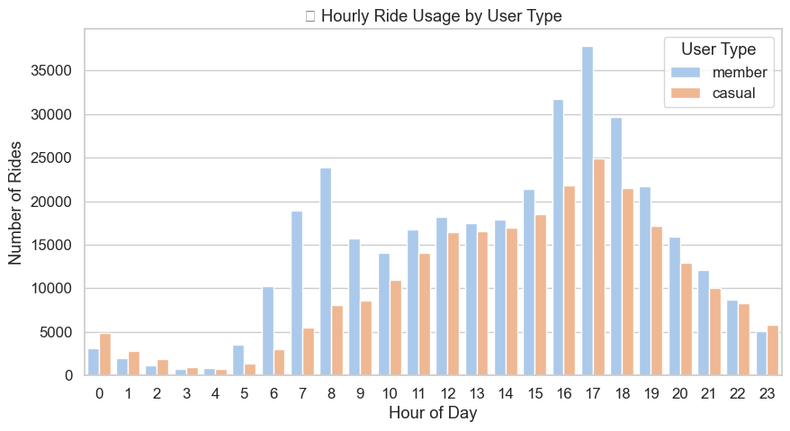

```python
plt.figure(figsize=(10,5))
sns.countplot(data=df, x='hour', hue='member_casual')
plt.title("🕘 Hourly Ride Usage by User Type")
plt.xlabel("Hour of Day")
plt.ylabel("Number of Rides")
plt.legend(title='User Type')
plt.show()
```

### ⏰ Usage Patterns by Time of Day

- **Casual riders** and **annual members** both predominantly use Cyclistic bikes **during daytime hours**, specifically between **12:00 PM and 7:00 PM**.
- This time window suggests that most rides occur during **leisure hours**, **lunch breaks**, or **commutes back home**.
- It highlights the importance of ensuring high bike availability and maintenance during these peak usage hours.

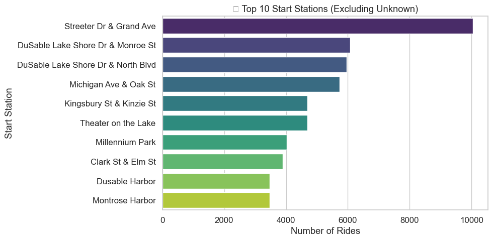

```python
valid_starts = df[~df['start_station_name'].isin(['Unknown', None, '', 'N/A'])]
top_starts = valid_starts['start_station_name'].value_counts().head(10)

plt.figure(figsize=(10, 5))
sns.barplot(x=top_starts.values, y=top_starts.index, palette='viridis')
plt.title("📍 Top 10 Start Stations (Excluding Unknown)")
plt.xlabel("Number of Rides")
plt.ylabel("Start Station")
plt.tight_layout()
plt.show()
```

### 📍 Start Station Trends

- Most popular start stations for all users are near tourist-heavy or lakefront areas, with **“Streeter Dr & Grand Ave”** topping the list.

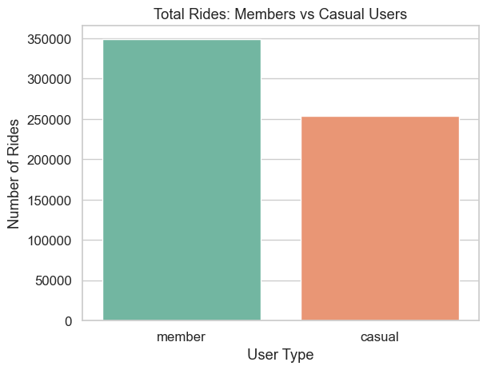

```python
sns.countplot(data=df, x='member_casual', palette='Set2')
plt.title("Total Rides: Members vs Casual Users")
plt.xlabel("User Type")
plt.ylabel("Number of Rides")
plt.show()
```

### 📈 Total Ride Volume

- **Members** take more rides overall than casual riders, showing stronger engagement and frequent usage.

```
Average Ride Duration (min):
 member_casual
casual    22.56
member    12.79
Name: ride_duration_min, dtype: float64
```

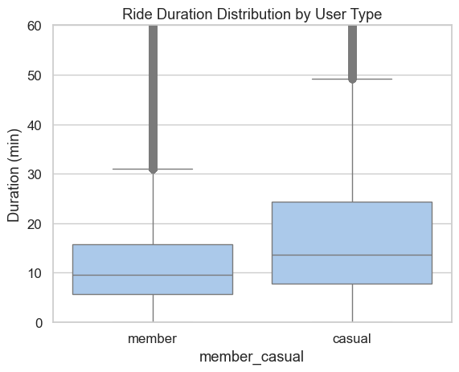

```python
avg_duration_user = df.groupby('member_casual')['ride_duration_min'].mean().round(2)
print("Average Ride Duration (min):\n", avg_duration_user)

sns.boxplot(data=df, x='member_casual', y='ride_duration_min')
plt.title("Ride Duration Distribution by User Type")
plt.ylabel("Duration (min)")
plt.ylim(0, 60)  # limit to avoid long tails
plt.show()
```

### ⏱️ Ride Duration

- Casual riders have longer average ride durations, suggesting recreational usage.
- Members take shorter, more consistent rides, likely for commuting or utility.

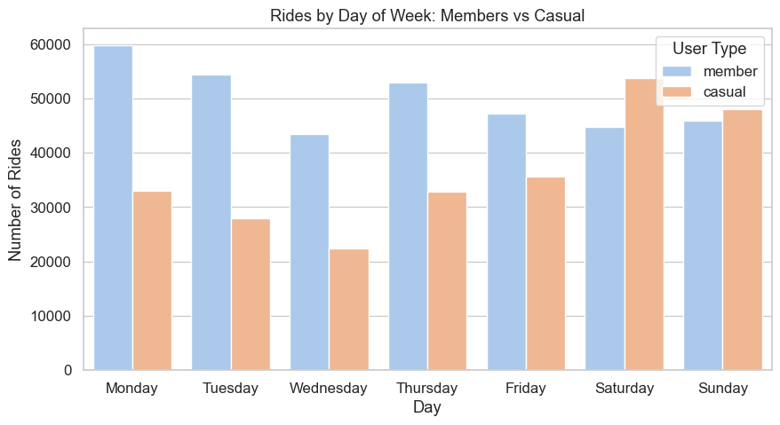

```python
# Order days
days_order = ['Monday', 'Tuesday', 'Wednesday', 'Thursday', 'Friday', 'Saturday', 'Sunday']

plt.figure(figsize=(10,5))
sns.countplot(data=df, x='day_of_week', hue='member_casual', order=days_order)
plt.title("Rides by Day of Week: Members vs Casual")
plt.xlabel("Day")
plt.ylabel("Number of Rides")
plt.legend(title="User Type")
plt.show()
```

### 📅 Weekly Usage Patterns

```python
clean_df = df[~df['start_station_name'].isin(['Unknown', None, '', 'N/A'])]
top_starts = (
    clean_df.groupby(['member_casual', 'start_station_name'])
    .size()
    .reset_index(name='ride_count')
    .sort_values(['member_casual', 'ride_count'], ascending=[True, False])
)

print("🚴 Top 10 Start Stations for Casual Riders:")
print(top_starts[top_starts['member_casual'] == 'casual'].head(10))

print("\n🚴‍♂️ Top 10 Start Stations for Members:")
print(top_starts[top_starts['member_casual'] == 'member'].head(10))
```

```
🚴 Top 10 Start Stations for Casual Riders:
     member_casual                  start_station_name  ride_count
1153        casual             Streeter Dr & Grand Ave        8068
291         casual   DuSable Lake Shore Dr & Monroe St        4754
666         casual               Michigan Ave & Oak St        3964
292         casual  DuSable Lake Shore Dr & North Blvd        3595
1157        casual                 Theater on the Lake        2916
673         casual                     Millennium Park        2892
295         casual                      Dusable Harbor        2592
1067        casual                      Shedd Aquarium        2410
686         casual                     Montrose Harbor        2170
661         casual               Michigan Ave & 8th St        1654

🚴‍♂️ Top 10 Start Stations for Members:
     member_casual                  start_station_name  ride_count
1764        member            Kingsbury St & Kinzie St        3371
1495        member        Clinton St & Washington Blvd        2528
1466        member                   Clark St & Elm St        2513
1572        member  DuSable Lake Shore Dr & North Blvd        2362
1491        member             Clinton St & Madison St        2256
2430        member                   Wells St & Elm St        2195
1415        member               Canal St & Madison St        2083
2429        member               Wells St & Concord Ln        2017
2374        member             Streeter Dr & Grand Ave        1970
2433        member                 Wells St & Huron St        1961
```

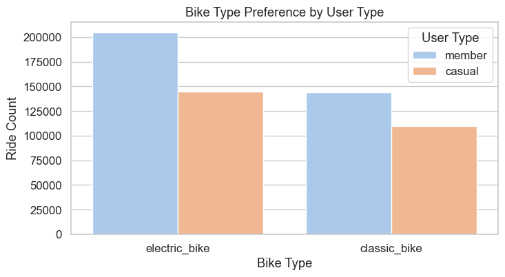

```python
plt.figure(figsize=(8,4))
sns.countplot(data=df, x='rideable_type', hue='member_casual')
plt.title("Bike Type Preference by User Type")
plt.xlabel("Bike Type")
plt.ylabel("Ride Count")
plt.legend(title="User Type")
plt.show()
```

### 📌 Business Question: How do annual members and casual riders use Cyclistic bikes differently?

Our analysis reveals clear behavioral differences:

- 🚴 **Casual Riders** mostly begin their rides from scenic, recreational locations such as Streeter Dr & Grand Ave, Millennium Park, and Theater on the Lake. These are popular tourist spots, indicating that casual riders typically use bikes for leisure and exploration, especially on weekends and holidays.
- 🧑‍💼 **Annual Members**, on the other hand, frequently start rides at stations near office areas, residential neighborhoods, and transit hubs like Kingsbury St, Clinton St, and Wells St. This suggests that members rely on bikes for **daily commuting**, errands, or consistent transportation needs.
- 📈 **Ride Duration & Frequency** : Casual riders usually take longer but less frequent rides, while members take shorter, more regular rides — reinforcing the recreational vs. utilitarian usage pattern.

Overall, **casual riders ride for fun**, and **members ride with purpose**. These insights are vital for shaping marketing strategies, pricing models, and expansion plans.